# MS Comprehensive Exam 2022

STA 207 (100 points)

**Read the instructions on Canvas carefully!**

**Name**:

**Student ID**:

```r
library(lme4)
```

In this exam, we investigate the `ChickWeight` dataset in `R`. You can load the data using the following commands. Carefully read the help file of `ChickWeight` before working on the following questions.

```r
data(ChickWeight)
```

**(a) Briefly summarize all variables in the data set. You need to provide the definition of the variable and quantitative summary.**

**Solution:** (Type your answer here)

Weight represents the body weight of chicken, and is a numeric vector.

Time represents the number of days from birth as the measurement was made.

Chick is an ordered factor with 50 levels, and is a unique identifier for the chick. The levels’ ordering puts together chicks on the same diet and arranges them from lightest to heaviest in terms of final weight.

Diet is an factor with 4 levels, which represent the diet type the chick recieved

```r
# (a). (Type your code in the space below, if any)
str(ChickWeight)
```

```
## Classes 'nfnGroupedData', 'nfGroupedData', 'groupedData' and 'data.frame':   578 obs. of  4 variables:
##  $ weight: num  42 51 59 64 76 93 106 125 149 171 ...
##  $ Time  : num  0 2 4 6 8 10 12 14 16 18 ...
##  $ Chick : Ord.factor w/ 50 levels "18"<"16"<"15"<..: 15 15 15 15 15 15 15 15 15 15 ...
##  $ Diet  : Factor w/ 4 levels "1","2","3","4": 1 1 1 1 1 1 1 1 1 1 ...
##  - attr(*, "formula")=Class 'formula'  language weight ~ Time | Chick
##   .. ..- attr(*, ".Environment")=<environment: R_EmptyEnv>
##  - attr(*, "outer")=Class 'formula'  language ~Diet
##   .. ..- attr(*, ".Environment")=<environment: R_EmptyEnv>
##  - attr(*, "labels")=List of 2
##   ..$ x: chr "Time"
##   ..$ y: chr "Body weight"
##  - attr(*, "units")=List of 2
##   ..$ x: chr "(days)"
##   ..$ y: chr "(gm)"
```

**(b) Visualize the weights of each chicks over time in one plot, where (i) each chick is represented by one solid curve, and (ii) the `diet` is color-coded as black (1), red (2), green (3), and blue (4). In addition to the required visualization, you may add any supporting curves, symbols, or any additional plots that you find informative.**

**Solution:** (Type your answer here)

Additionally, the plot below shows that the third diet type results in the highest average weight gain for the chick.

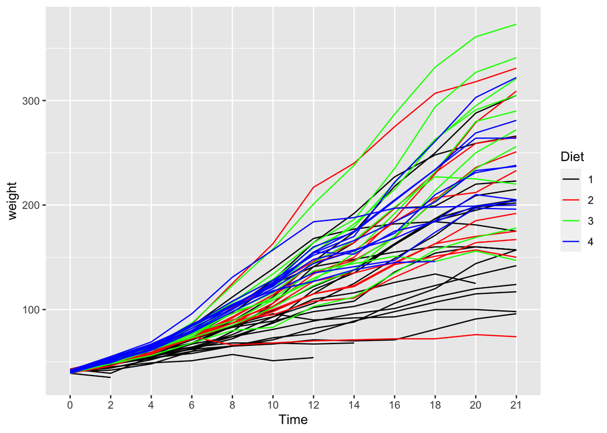

```r
# (b). (Type your code in the space below, if any)
library(ggplot2)
ChickWeight$Time<-as.factor(ChickWeight$Time)
p<-ggplot(data=ChickWeight, aes(x=Time, y=weight, group=Chick)) +
  geom_line(aes(color=Diet))
p+scale_color_manual(values=c("black", "red","green","blue"))
```

```r
library(dplyr)
ChickWeight%>%group_by(Chick)%>%summarise(count=n(),gain_weight=max(weight)-min(weight),diet_type=sum(as.numeric(Diet))/length(Chick))->newdata
```

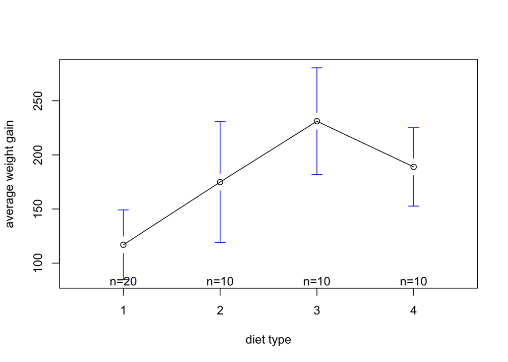

```r
library(gplots)
plotmeans(gain_weight~as.factor(diet_type),data=newdata,xlab="diet type",ylab="average weight gain")
```

**(c) Write down an appropriate one-way ANOVA model to answer the question whether there is any changes in mean weights at Day 20 across the four diet group. To receive full credits, you need to (i) write down the model, explain your notation, constraint(s) and/or assumptions; (ii) state the null and alternative hypotheses; (iii) state the test result. You can find basic LaTeX commands at the end of this file.**

**Solution:** (Type your answer here)

$Y_{ij}=\mu_{..}+\alpha_i+\epsilon_{ij}$ i=1,2,3,4, j=1,2..$n_{i}$

$\mu_{..} :$ represents the overall mean weight of chick at day 20.

$\alpha_i :$ represents the fixed effect of $i^{th}$ diet type, $\sum_{i=1}^{4} \alpha_i=0$.

- i=1: diet type=1
- i=2: diet type=2
- i=3: diet type=3
- i=4: diet type=4

$\epsilon_{ij} :$ represents the residual of $j^{th}$ chick’s weight at $i^{th}$ diet type. $\epsilon_{ij} \sim N(0,\sigma^2)$

Due to the unbalanced data, the first diet type has 17 data points, the fourth diet type has 9 data points, and the third and second diet types have 10 data points each. Therefore, we will use a Type II ANOVA to answer this question.

```r
# (c). (Type your code in the space below, if any)
library(pander)
data_c<-ChickWeight[ChickWeight$Time==20,]
data_c%>%group_by(Diet)%>%summarise(count=n())->one_way_count
pander(one_way_count)
```

| Diet | count |
| --- | --- |
| 1 | 17 |
| 2 | 10 |
| 3 | 10 |
| 4 | 9 |

#### hypothesis:

$H_0 :\space \alpha_i=0$ for i in 1,2,3,4

$H_1: \space \alpha_i \neq0$ for i in 1,2,3,4

Based on the F test, we learn that the p-value (2.909 x $10^{-3}$) is small enough, p-value is smaller than 0.01, to reject the null hypothesis. Hence, we will keep $\alpha_i$ in this model.

```r
fit.1=lm(weight ~Diet,data=data_c)
fit.1=car::Anova(fit.1, type = 2)
fit.1
```

```
## Anova Table (Type II tests)
##
## Response: weight
##           Sum Sq Df F value   Pr(>F)
## Diet       55881  3  5.4636 0.002909 **
## Residuals 143190 42
## ---
## Signif. codes:  0 '***' 0.001 '**' 0.01 '*' 0.05 '.' 0.1 ' ' 1
```

**(d) For the model fitted in (c), carry out necessary diagnostics to check if the model assumptions are valid. What are your findings?**

**Solution:** (Type your answer here)

**homogeneity of variance assumption**

$H_0:\space \sigma^2_1=\sigma^2_2=\sigma^2_3=\sigma^2_4$

$H_0 :\space\sigma^2_i\neq\sigma^2_j$ i=1,2,3,4, j=1,2,3,4, $i \neq j$

p-value bigger than 0.05, so we do not reject null hypothesis, the model follow variance of homogeneity, known as homoscedasticity.

```r
# (d). (Type your code in the space below, if any)
model=lm(weight ~Diet,data=data_c)

library(car)
result<-leveneTest(weight ~Diet,data=data_c)
print(result)
```

```
## Levene's Test for Homogeneity of Variance (center = median)
##       Df F value Pr(>F)
## group  3  1.1111 0.3553
##       42
```

**Normality assumption**

From the normal QQ-plot, it has a heavy-tailed distribution at the right side. Based on our observations of the diagonal line, we can generally conclude that the model adheres to the normality assumption..

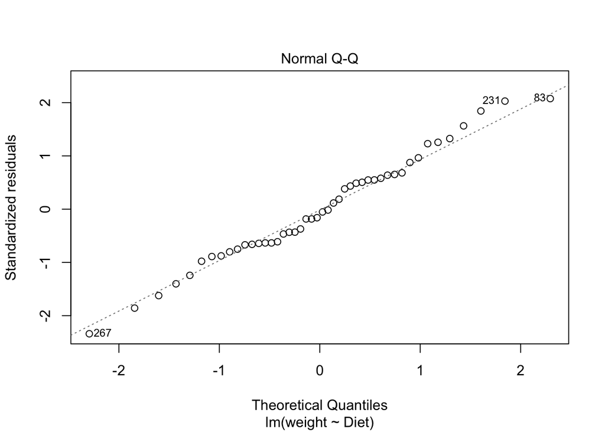

```r
plot(model, which=c(2))
```

**(e) Write down an appropriate two-way ANOVA model with fixed effect to answer the question whether there is any differences in growth rates across the four diet groups. Here the growth rate can be roughly seen as the effects of `Time` on `weight`. To receive full credits, you need to (i) write down the model, explain your notation, constraint(s) and/or assumptions; (ii) state the null and alternative hypotheses; (iii) state the test result. Hint: You may want to recycle the answer in (c) to save time.**

**Solution:** (Type your answer here)

```r
# (e). (Type your code in the space below, if any)
fit.2=lm(weight~Time+Diet,data=ChickWeight)
fit.2=car::Anova(fit.2, type=2)
fit.2
```

```
## Anova Table (Type II tests)
##
## Response: weight
##            Sum Sq  Df F value    Pr(>F)
## Time      2040908  11 145.527 < 2.2e-16 ***
## Diet       129721   3  33.916 < 2.2e-16 ***
## Residuals  717785 563
## ---
## Signif. codes:  0 '***' 0.001 '**' 0.01 '*' 0.05 '.' 0.1 ' ' 1
```

**(f) We want to take the chick-specific effect into account. The new mixed effect model is based on the model in (e), where `Time` is treated as a continuous covariate instead of a categorical factor, and a random intercept and a random slope (of `Time`) are added into the model. Report the fitted coefficients of the fixed effects, and summarize your findings from this model. Hint: You do not need to write down the new model, but you may find it helpful.**

**Solution:** (Type your answer here)

$Y_{ijk}=\mu_{…}+\alpha_i+\beta_j+\epsilon_{ijk}$

$Y_{ijk} :$ represents the weight of $k^{th}$ chick under $i^{th}$ diet type and $j^{th}$ time.

$\mu_{…} :$ represents the overall mean weight of $k^{th}$ chick under $i^{th}$ diet type at $j^{th}$ time.

$\alpha_i :$ represents the fixed effect of $i^{th}$ diet type. $\sum_{i=1}^{4}\alpha_i=0$

$\beta_j :$ represents the random effect of $j^{th}$ time. $\beta_j\sim N(0,\sigma_{\beta}^2)$

$\epsilon_{ijk}:$ represents the residual of weights of $k^{th}$ chick across $i^{th}$ diet type and $j^{th}$ time.$\epsilon_{ij} \sim N(0,\sigma^2)$

Besides, proportion of variability that is due to variability in time is 63.5%, which is calculated from $\sigma_{\beta}/(\sigma_{\beta}+\sigma)$.

The fitted coefficients of the fixed effects:

- i=1: diet type=1, fitted coefficient=0, because we take type 1 diet as baseline.
- i=2: diet type=2, fitted coefficient=16.13
- i=3: diet type=3, fitted coefficient=36.46
- i=4: diet type=4, fitted coefficient=30.29

Based on the coefficients that have been fitted above, it is clear that diet 3 will be the most effective in promoting weight gain in chicks.

```r
# (f). (Type your code in the space below, if any)
library("lme4")
options(contrasts = c("contr.treatment", "contr.poly"))
fit.full <- lmer(weight~Diet+(1|Time),data=ChickWeight)
fit.full
```

```
## Linear mixed model fit by REML ['lmerMod']
## Formula: weight ~ Diet + (1 | Time)
##    Data: ChickWeight
## REML criterion at convergence: 5808.069
## Random effects:
##  Groups   Name        Std.Dev.
##  Time     (Intercept) 62.25
##  Residual             35.71
## Number of obs: 578, groups:  Time, 12
## Fixed Effects:
## (Intercept)        Diet2        Diet3        Diet4
##      106.49        16.13        36.46        30.29
```

**(g) Assume that the chicks in each diet are randomly selected from the same population, i.e., the enrollment of chicks is independent from any other factors. State the Stable Unit Treatment Value Assumption, write down the potential outcomes (weight at Day 20), and verify whether the randomization assumption holds. (This question will be replaced by another, since causal inference will not be covered this quarter.)**

**Solution:** (Type your answer here)

**LaTeX commands**

$$Y_{i,j,k}, \mu, \alpha, \beta, \epsilon,
i, j, H_0, H_a, \neq, =, \ldots$$